# ANOVA

Esko

22.08.2016

In the following, we will demonstrate how you would calculate one way or two-way ANOVAs in R.

We will use the same data as in the *Testing for association between two continous variables*.

```r
game.wmc <- read.table("kr_gamewmc.txt", header=T)
game.wmc$accuracy <- game.wmc$Phit + game.wmc$PcorrectRejection
```

Then we will investigate accuracy as a function of age group and gender.

Basically, because we are using a linear model, we can use function lm.

```r
# single main effect models
fm.a <- lm(accuracy ~ age_grp, game.wmc)
fm.g <- lm(accuracy ~ gender, game.wmc)

# both main effects
fm.ag <- lm(accuracy ~ age_grp + gender, game.wmc)

# main effects and interaction
fm.ag <- lm(accuracy ~ age_grp * gender, game.wmc)

# this a shorthand for writing
fm.ag2 <- lm(accuracy ~ age_grp + gender + age_grp:gender, game.wmc)
```

We could use function anova to compare the models, and then select what to choose. But what if we would like to get the F-values for effects, in the exactly same way as in SPSS?

We could write

```r
anova(fm.ag)
```

```
## Analysis of Variance Table
##
## Response: accuracy
##                Df   Sum Sq  Mean Sq F value   Pr(>F)
## age_grp         1 0.048276 0.048276 10.4181 0.006076 **
## gender          1 0.000088 0.000088  0.0189 0.892631
## age_grp:gender  1 0.000010 0.000010  0.0021 0.964107
## Residuals      14 0.064874 0.004634
## ---
## Signif. codes:  0 '***' 0.001 '**' 0.01 '*' 0.05 '.' 0.1 ' ' 1
```

Unfortunately, this may not be what you wanted. Especially, the output is not the same as in SPSS by default.

## R’s anova calculates Type I Sum of Squares

R’s anova function give type I Sum of Squares, but SPSS tells us type III Sum of Squares by default. We can get type III Sum of Squares using function Anova from package car.

```r
anova(fm.ag)
```

```
## Analysis of Variance Table
##
## Response: accuracy
##                Df   Sum Sq  Mean Sq F value   Pr(>F)
## age_grp         1 0.048276 0.048276 10.4181 0.006076 **
## gender          1 0.000088 0.000088  0.0189 0.892631
## age_grp:gender  1 0.000010 0.000010  0.0021 0.964107
## Residuals      14 0.064874 0.004634
## ---
## Signif. codes:  0 '***' 0.001 '**' 0.01 '*' 0.05 '.' 0.1 ' ' 1
```

```r
library(car)
Anova(fm.ag, type=3)
```

```
## Anova Table (Type III tests)
##
## Response: accuracy
##                 Sum Sq Df  F value    Pr(>F)
## (Intercept)    1.41716  1 305.8253 6.578e-11 ***
## age_grp        0.02108  1   4.5495   0.05111 .
## gender         0.00001  1   0.0012   0.97340
## age_grp:gender 0.00001  1   0.0021   0.96411
## Residuals      0.06487 14
## ---
## Signif. codes:  0 '***' 0.001 '**' 0.01 '*' 0.05 '.' 0.1 ' ' 1
```

If you compare the outputs, you will see that the results are different.

## Type of Sum of Squares matters when the data is unbalanced

Both methods would produce exactly the same results, if the data were balanced. However, we have a different number of males in adult group than in children group etc. (You could actually ask if there is any point to make ANOVA with small number of observations, but let’s continue anyway.)

```r
with(game.wmc, table(age_grp, gender))
```

```
##        gender
## age_grp Mies Nainen
##       A    2      3
##       C    8      5
```

*anova* function uses type I Sum of Squares. So when the data is unbalanced, the order in which the predictors are included in the model matters. The first predictor explains most of the variation, the second explains the portion of variance left over from the first predictor etc. In the case of an unbalanced design, this amounts to comparing group means weighted by their individual sample sizes, which is something that the researcher is not usually interested in. For a fine discussion of these issues, see the [presentation by Zhan](http://md.psych.bio.uni-goettingen.de/mv/unit/lm_cat/InteractionsAndTypesOfSS.pdf).

In many cases, the resercher is interested in the unweighted means. That is, what is the effect after controlling for every other effect. Consequently, the rule of thumb is to ‘always’ use type III Sum of Squares.

## Things to note with type III Sum of Squares

Before calculating anovas using R, set the default contrasts to orthogonal, if you want to obtain results that are comparable to those produced by SPSS.

Especially, if you want to use type III Sum of Squares like in SPSS by default, you MUST use orthogonal contrasts! Otherwise your results may be wrong.

```r
# for checking what the defaults contrasts are
options("contrasts")
```

```
## $contrasts
##         unordered           ordered
## "contr.treatment"      "contr.poly"
```

```r
# For setting orthogonal contrasts,
# sum to zero for factors, polynomial for ordered.
#
# ALWAYS SET ORTHOGONAL CONTRASTS BEFORE USING TYPE III SUM OF SQUARES
#
options(contrasts = c("contr.sum", "contr.poly"))
fm.ag <- lm(accuracy ~ age_grp * gender, game.wmc)
Anova(fm.ag, type=3)
```

```
## Anova Table (Type III tests)
##
## Response: accuracy
##                Sum Sq Df   F value    Pr(>F)
## (Intercept)    8.4574  1 1825.1238 3.113e-16 ***
## age_grp        0.0468  1   10.1082   0.00669 **
## gender         0.0000  1    0.0107   0.91911
## age_grp:gender 0.0000  1    0.0021   0.96411
## Residuals      0.0649 14
## ---
## Signif. codes:  0 '***' 0.001 '**' 0.01 '*' 0.05 '.' 0.1 ' ' 1
```

```r
# By default, R uses treatment contrast for factors.
# This DOES NOT WORK correctly with type III Sum of Squares.
#
# DO NOT USE TREATMENT CONTRAST WITH TYPE III SUM OF SQUARES.
#
options(contrasts = c("contr.treatment", "contr.poly"))
fm.ag <- lm(accuracy ~ age_grp * gender, game.wmc)
Anova(fm.ag, type=3)
```

```
## Anova Table (Type III tests)
##
## Response: accuracy
##                 Sum Sq Df  F value    Pr(>F)
## (Intercept)    1.41716  1 305.8253 6.578e-11 ***
## age_grp        0.02108  1   4.5495   0.05111 .
## gender         0.00001  1   0.0012   0.97340
## age_grp:gender 0.00001  1   0.0021   0.96411
## Residuals      0.06487 14
## ---
## Signif. codes:  0 '***' 0.001 '**' 0.01 '*' 0.05 '.' 0.1 ' ' 1
```

## Do not use type III Sum of Squares blindly

The obvious question is why there are multiple types of Sum of Squares. Consider the following ANCOVA model, where we try to explain *accuracy* by working memory capacity *pcu_score* and *age_grp*.

It is not a surprice that adults have a higher working memory capacity than children.

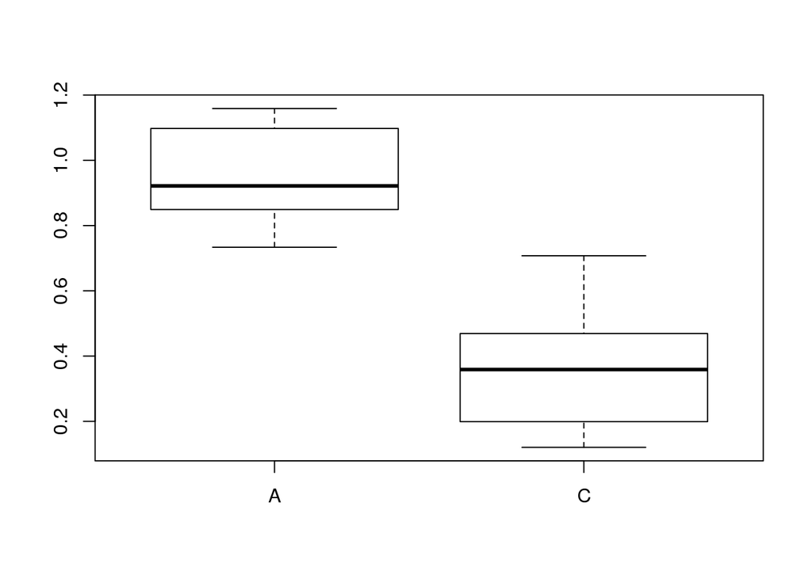

```r
boxplot(pcu_score ~ age_grp, game.wmc)
```

*pcu_score* predicts *accuracy*, as does *age_grp*.

```r
fm.wmc <- lm(accuracy ~ pcu_score, game.wmc)
summary(fm.wmc)
```

```
##
## Call:
## lm(formula = accuracy ~ pcu_score, data = game.wmc)
##
## Residuals:
##       Min        1Q    Median        3Q       Max
## -0.132393 -0.048786  0.009514  0.045519  0.101660
##
## Coefficients:
##             Estimate Std. Error t value Pr(>|t|)
## (Intercept)  0.66200    0.03012  21.981    8e-13 ***
## pcu_score    0.17422    0.04833   3.605   0.0026 **
## ---
## Signif. codes:  0 '***' 0.001 '**' 0.01 '*' 0.05 '.' 0.1 ' ' 1
##
## Residual standard error: 0.06337 on 15 degrees of freedom
##   (1 observation deleted due to missingness)
## Multiple R-squared:  0.4642, Adjusted R-squared:  0.4285
## F-statistic:    13 on 1 and 15 DF,  p-value: 0.002599
```

```r
anova(fm.wmc) # ok to use type I Sum of Squares, because we have only one predictor
```

```
## Analysis of Variance Table
##
## Response: accuracy
##           Df   Sum Sq  Mean Sq F value   Pr(>F)
## pcu_score  1 0.052190 0.052190  12.996 0.002599 **
## Residuals 15 0.060239 0.004016
## ---
## Signif. codes:  0 '***' 0.001 '**' 0.01 '*' 0.05 '.' 0.1 ' ' 1
```

```r
fm.age <- lm(accuracy ~ age_grp, game.wmc)
summary(fm.age)
```

```
##
## Call:
## lm(formula = accuracy ~ age_grp, data = game.wmc)
##
## Residuals:
##       Min        1Q    Median        3Q       Max
## -0.129946 -0.029955 -0.000487  0.034186  0.110560
##
## Coefficients:
##             Estimate Std. Error t value Pr(>|t|)
## (Intercept)  0.84051    0.02850  29.493 2.24e-15 ***
## age_grpC    -0.11562    0.03353  -3.448  0.00331 **
## ---
## Signif. codes:  0 '***' 0.001 '**' 0.01 '*' 0.05 '.' 0.1 ' ' 1
##
## Residual standard error: 0.06372 on 16 degrees of freedom
## Multiple R-squared:  0.4263, Adjusted R-squared:  0.3904
## F-statistic: 11.89 on 1 and 16 DF,  p-value: 0.003308
```

```r
anova(fm.wmc)
```

```
## Analysis of Variance Table
##
## Response: accuracy
##           Df   Sum Sq  Mean Sq F value   Pr(>F)
## pcu_score  1 0.052190 0.052190  12.996 0.002599 **
## Residuals 15 0.060239 0.004016
## ---
## Signif. codes:  0 '***' 0.001 '**' 0.01 '*' 0.05 '.' 0.1 ' ' 1
```

But if we combine both, and use type III Sum of Squares, we get perplexing result

```r
options(contrasts = c("contr.sum", "contr.poly"))
fm.axw <- lm(accuracy ~ pcu_score + age_grp, game.wmc)
summary(fm.axw)
```

```
##
## Call:
## lm(formula = accuracy ~ pcu_score + age_grp, data = game.wmc)
##
## Residuals:
##       Min        1Q    Median        3Q       Max
## -0.126185 -0.040407  0.009071  0.043886  0.110670
##
## Coefficients:
##             Estimate Std. Error t value Pr(>|t|)
## (Intercept)  0.71538    0.06174  11.586 1.47e-08 ***
## pcu_score    0.09861    0.09036   1.091    0.294
## age_grp1     0.03124    0.03153   0.991    0.339
## ---
## Signif. codes:  0 '***' 0.001 '**' 0.01 '*' 0.05 '.' 0.1 ' ' 1
##
## Residual standard error: 0.06341 on 14 degrees of freedom
##   (1 observation deleted due to missingness)
## Multiple R-squared:  0.4993, Adjusted R-squared:  0.4278
## F-statistic: 6.981 on 2 and 14 DF,  p-value: 0.007889
```

```r
Anova(fm.axw, type=3)
```

```
## Anova Table (Type III tests)
##
## Response: accuracy
##              Sum Sq Df  F value    Pr(>F)
## (Intercept) 0.53976  1 134.2386 1.466e-08 ***
## pcu_score   0.00479  1   1.1908    0.2936
## age_grp     0.00395  1   0.9814    0.3387
## Residuals   0.05629 14
## ---
## Signif. codes:  0 '***' 0.001 '**' 0.01 '*' 0.05 '.' 0.1 ' ' 1
```

Anova tells us that neither of the effects is significant. This is because with type III, each effect is evaluated after controlling for all the others. Because pcu_score and age_grp are very strongly correlated, there is no variation left to be explained.

```r
anova(fm.axw)
```

```
## Analysis of Variance Table
##
## Response: accuracy
##           Df   Sum Sq  Mean Sq F value   Pr(>F)
## pcu_score  1 0.052190 0.052190 12.9796 0.002883 **
## age_grp    1 0.003946 0.003946  0.9814 0.338664
## Residuals 14 0.056293 0.004021
## ---
## Signif. codes:  0 '***' 0.001 '**' 0.01 '*' 0.05 '.' 0.1 ' ' 1
```